# Analytics Case

### Problem Statement

Optimize marketing campaigns by focusing only on prospects and customers who are most likely react positively and show high propensity to buy the products

### Exploring the data

Importing and basic data analysis

```python
import pandas as pd
import numpy as np
import matplotlib.pyplot as plt
import seaborn as sns
from IPython.display import display,Markdown
from sklearn.preprocessing import MinMaxScaler
from sklearn.model_selection import train_test_split
pd.options.display.max_columns= None
```

```python
sheet= pd.ExcelFile('/Users/pushkarsinghbhauryal/Downloads/Analytical Interview DATASET.XLSX')
```

```python
customer_profile=  pd.read_excel(sheet,0)
customer_purchase=  pd.read_excel(sheet,1)
campaign_coverage=  pd.read_excel(sheet,2)
customer_data_monthlly=  pd.read_excel(sheet,3)
customer_socio_Economic=  pd.read_excel(sheet,4)
```

### Exploring the customer profile data

In this section we will look for missing data, outlier and basic analysis

```python
display(customer_profile.info())
```

```
<class 'pandas.core.frame.DataFrame'>
RangeIndex: 5148 entries, 0 to 5147
Data columns (total 13 columns):
Customer_ID              5148 non-null int64
age                      5148 non-null int64
job                      5148 non-null object
marital_status           5148 non-null object
education                5148 non-null object
Previous_Default_Flag    4066 non-null object
House_Owned_Flag         5148 non-null object
Loan_Availed_Flag        5032 non-null object
Income_USD               5148 non-null int64
Credit_rating            5148 non-null object
Life_Stage_Code          5148 non-null object
Ethnicity                5148 non-null object
Employment               5148 non-null object
dtypes: int64(3), object(10)
memory usage: 522.9+ KB
```

```
None
```

```python
# We can see that Previous_Default_Flag have a large amount of NaN
# Few NaN with Loan_Availed_Flag
display(customer_profile.head())
print('\nPercentage of missing data in Previous_Default_Flag columns {}%'.format(sum(pd.isna(customer_profile.Previous_Default_Flag))/ customer_profile.shape[0]))
print('\nPercentage of missing data in Loan_Availed_Flag columns {}%'.format(sum(pd.isna(customer_profile.Loan_Availed_Flag))/ customer_profile.shape[0]))
```

|  | Customer_ID | age | job | marital_status | education | Previous_Default_Flag | House_Owned_Flag | Loan_Availed_Flag | Income_USD | Credit_rating | Life_Stage_Code | Ethnicity | Employment |
| --- | --- | --- | --- | --- | --- | --- | --- | --- | --- | --- | --- | --- | --- |
| 0 | 1 | 85 | retired | married | basic.4y | no | no | no | 10307 | Poor | Tradinationalist | African American | retired |
| 1 | 2 | 50 | blue-collar | married | basic.9y | no | no | no | 33232 | Fair | Baby Boomers | African American | employed |
| 2 | 3 | 47 | blue-collar | single | basic.4y | NaN | no | no | 12167 | Fair | Baby Boomers | African American | employed |
| 3 | 4 | 26 | technician | divorced | professional.course | no | no | yes | 26459 | Good | Gen Y | African American | employed |
| 4 | 5 | 52 | retired | married | university.degree | NaN | no | no | 22328 | Good | Baby Boomers | African American | retired |

```
Percentage of missing data in Previous_Default_Flag columns 0.21017871017871018%

Percentage of missing data in Loan_Availed_Flag columns 0.022533022533022532%
```

### Dealing with missing values

Since there is no previous record is available for the **Previous_Default_Flag** for some customer and NaN % is high so I replace NaN with No. Since **Loan_Availed_Flag** is NaN for small amount of data. so, I removed those rows

```python
customer_profile.Previous_Default_Flag=customer_profile.Previous_Default_Flag.apply(lambda x: 'no' if pd.isna(x) else x)
customer_profile=customer_profile.dropna().reset_index()
display(customer_profile.info())
display(customer_profile.head())
```

```
<class 'pandas.core.frame.DataFrame'>
RangeIndex: 5032 entries, 0 to 5031
Data columns (total 14 columns):
index                    5032 non-null int64
Customer_ID              5032 non-null int64
age                      5032 non-null int64
job                      5032 non-null object
marital_status           5032 non-null object
education                5032 non-null object
Previous_Default_Flag    5032 non-null object
House_Owned_Flag         5032 non-null object
Loan_Availed_Flag        5032 non-null object
Income_USD               5032 non-null int64
Credit_rating            5032 non-null object
Life_Stage_Code          5032 non-null object
Ethnicity                5032 non-null object
Employment               5032 non-null object
dtypes: int64(4), object(10)
memory usage: 550.5+ KB
```

```
None
```

|  | index | Customer_ID | age | job | marital_status | education | Previous_Default_Flag | House_Owned_Flag | Loan_Availed_Flag | Income_USD | Credit_rating | Life_Stage_Code | Ethnicity | Employment |
| --- | --- | --- | --- | --- | --- | --- | --- | --- | --- | --- | --- | --- | --- | --- |
| 0 | 0 | 1 | 85 | retired | married | basic.4y | no | no | no | 10307 | Poor | Tradinationalist | African American | retired |
| 1 | 1 | 2 | 50 | blue-collar | married | basic.9y | no | no | no | 33232 | Fair | Baby Boomers | African American | employed |
| 2 | 2 | 3 | 47 | blue-collar | single | basic.4y | no | no | no | 12167 | Fair | Baby Boomers | African American | employed |
| 3 | 3 | 4 | 26 | technician | divorced | professional.course | no | no | yes | 26459 | Good | Gen Y | African American | employed |
| 4 | 4 | 5 | 52 | retired | married | university.degree | no | no | no | 22328 | Good | Baby Boomers | African American | retired |

### Checking of data distribution and outlier

We have two numerical values in this table let’s check the data distribution and if there is any outlier

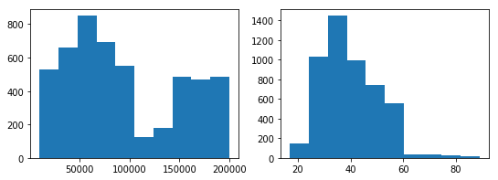

```python
fig, axs = plt.subplots(1, 2, figsize=(9, 3), sharey=False);
axs[0].hist(customer_profile.Income_USD);
axs[1].hist(customer_profile.age);
```

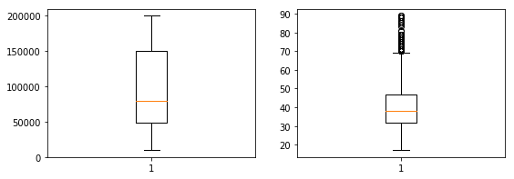

```python
fig, axs = plt.subplots(1, 2, figsize=(9, 3), sharey=False);
axs[0].boxplot(customer_profile.Income_USD);
axs[1].boxplot(customer_profile.age);
```

As we can see there are some outlier in age in upper range. Let’s look the raw data for the outlier.

```python
age_gr_70 = customer_profile.age>70
# lets look into actual data
display(customer_profile[age_gr_70])
# Data looks correct so no need of any further action
```

|  | index | Customer_ID | age | job | marital_status | education | Previous_Default_Flag | House_Owned_Flag | Loan_Availed_Flag | Income_USD | Credit_rating | Life_Stage_Code | Ethnicity | Employment |
| --- | --- | --- | --- | --- | --- | --- | --- | --- | --- | --- | --- | --- | --- | --- |
| 0 | 0 | 1 | 85 | retired | married | basic.4y | no | no | no | 10307 | Poor | Tradinationalist | African American | retired |
| 111 | 111 | 112 | 89 | retired | divorced | basic.4y | no | no | no | 35988 | High Risk | Tradinationalist | African American | retired |
| 203 | 205 | 206 | 88 | retired | divorced | basic.4y | no | yes | no | 15146 | Good | Tradinationalist | African American | retired |
| 224 | 227 | 228 | 77 | retired | married | university.degree | no | no | no | 18155 | Good | Tradinationalist | African American | retired |
| 337 | 345 | 346 | 75 | retired | married | basic.4y | no | no | no | 37057 | Poor | Tradinationalist | African American | retired |
| 405 | 415 | 416 | 79 | retired | married | high.school | no | yes | yes | 23244 | Good | Tradinationalist | African American | retired |
| 508 | 521 | 522 | 85 | retired | married | basic.4y | no | yes | no | 30674 | Poor | Tradinationalist | African American | retired |
| 624 | 637 | 638 | 79 | retired | married | basic.9y | no | no | no | 17301 | Excellent | Tradinationalist | African American | retired |
| 667 | 681 | 682 | 71 | retired | single | university.degree | no | no | no | 17562 | Fair | Tradinationalist | African American | retired |
| 812 | 833 | 834 | 78 | retired | married | basic.9y | no | yes | no | 29366 | Fair | Tradinationalist | African American | retired |
| 829 | 852 | 853 | 75 | housemaid | divorced | basic.4y | no | no | no | 38541 | Excellent | Tradinationalist | African American | employed |
| 933 | 958 | 959 | 74 | retired | divorced | university.degree | no | yes | no | 56870 | Good | Tradinationalist | Hispanic | retired |
| 954 | 980 | 981 | 78 | retired | divorced | basic.6y | no | no | no | 60283 | Good | Tradinationalist | Hispanic | retired |
| 1033 | 1061 | 1062 | 76 | retired | divorced | basic.4y | no | no | no | 46342 | Fair | Tradinationalist | Hispanic | retired |
| 1130 | 1160 | 1161 | 76 | retired | married | basic.4y | no | yes | no | 58093 | Good | Tradinationalist | Hispanic | retired |
| 1131 | 1161 | 1162 | 71 | retired | married | basic.4y | no | yes | no | 68724 | Poor | Tradinationalist | Hispanic | retired |
| 1267 | 1301 | 1302 | 77 | retired | married | university.degree | no | yes | no | 43058 | Poor | Tradinationalist | Hispanic | retired |
| 1321 | 1356 | 1357 | 71 | retired | married | university.degree | no | no | no | 46294 | Fair | Tradinationalist | Hispanic | retired |
| 1370 | 1406 | 1407 | 84 | retired | divorced | basic.4y | no | no | no | 50245 | Poor | Tradinationalist | Hispanic | retired |
| 1448 | 1486 | 1487 | 75 | housemaid | divorced | basic.4y | no | no | no | 48854 | Poor | Tradinationalist | Hispanic | employed |
| 1486 | 1526 | 1527 | 75 | retired | married | basic.4y | no | no | no | 52803 | High Risk | Tradinationalist | Hispanic | retired |
| 1495 | 1535 | 1536 | 85 | retired | married | professional.course | no | no | no | 53091 | Fair | Tradinationalist | Hispanic | retired |
| 1698 | 1742 | 1743 | 73 | retired | married | basic.4y | no | yes | no | 47635 | Poor | Tradinationalist | Hispanic | retired |
| 1718 | 1762 | 1763 | 86 | retired | married | basic.4y | no | yes | yes | 56135 | Excellent | Tradinationalist | Hispanic | retired |
| 1742 | 1786 | 1787 | 73 | retired | divorced | basic.4y | no | yes | no | 44492 | Fair | Tradinationalist | Hispanic | retired |
| 1774 | 1819 | 1820 | 74 | retired | divorced | basic.4y | no | yes | yes | 41728 | Excellent | Tradinationalist | Hispanic | retired |
| 1825 | 1870 | 1871 | 88 | retired | divorced | basic.4y | no | yes | yes | 64121 | Fair | Tradinationalist | Hispanic | retired |
| 1858 | 1903 | 1904 | 71 | retired | married | university.degree | no | yes | yes | 67507 | Fair | Tradinationalist | Hispanic | retired |
| 2041 | 2089 | 2090 | 77 | retired | divorced | basic.4y | no | no | no | 63772 | Excellent | Tradinationalist | Hispanic | retired |
| 2120 | 2173 | 2174 | 88 | retired | divorced | basic.4y | no | yes | no | 52280 | Excellent | Tradinationalist | Hispanic | retired |
| 2147 | 2200 | 2201 | 71 | retired | married | basic.9y | no | yes | yes | 59684 | Good | Tradinationalist | Hispanic | retired |
| 2150 | 2203 | 2204 | 88 | retired | divorced | high.school | no | yes | no | 64394 | Fair | Tradinationalist | Hispanic | retired |
| 2606 | 2667 | 2668 | 76 | retired | single | basic.4y | no | no | no | 74626 | Poor | Tradinationalist | Asian | retired |
| 2877 | 2946 | 2947 | 81 | retired | divorced | basic.4y | no | yes | no | 86727 | High Risk | Tradinationalist | Asian | retired |
| 2901 | 2971 | 2972 | 71 | retired | married | basic.4y | no | yes | no | 77796 | High Risk | Tradinationalist | Asian | retired |
| 2972 | 3043 | 3044 | 83 | housemaid | divorced | basic.4y | no | yes | no | 98460 | Excellent | Tradinationalist | Asian | employed |
| 3074 | 3148 | 3149 | 71 | retired | married | professional.course | no | no | no | 82051 | Excellent | Tradinationalist | Asian | retired |
| 3076 | 3150 | 3151 | 79 | retired | married | basic.4y | no | yes | no | 90781 | Good | Tradinationalist | Asian | retired |
| 3195 | 3270 | 3271 | 75 | retired | married | basic.9y | no | no | no | 93238 | Fair | Tradinationalist | Asian | retired |
| 3385 | 3465 | 3466 | 81 | retired | married | high.school | no | no | no | 132226 | Fair | Tradinationalist | American Indian | retired |
| 3440 | 3521 | 3522 | 88 | retired | married | university.degree | no | yes | no | 115039 | Fair | Tradinationalist | American Indian | retired |
| 3570 | 3652 | 3653 | 89 | retired | divorced | basic.4y | no | yes | no | 174115 | Fair | Tradinationalist | White | retired |
| 3719 | 3802 | 3803 | 71 | retired | single | university.degree | no | yes | no | 163252 | Excellent | Tradinationalist | White | retired |
| 3848 | 3931 | 3932 | 77 | management | married | university.degree | no | yes | no | 185099 | Poor | Tradinationalist | White | employed |
| 3971 | 4057 | 4058 | 75 | retired | divorced | basic.4y | no | yes | yes | 164637 | Good | Tradinationalist | White | retired |
| 4010 | 4098 | 4099 | 86 | retired | married | basic.4y | no | yes | no | 177291 | Fair | Tradinationalist | White | retired |
| 4015 | 4103 | 4104 | 76 | retired | divorced | basic.4y | no | yes | no | 144750 | Excellent | Tradinationalist | White | retired |
| 4166 | 4257 | 4258 | 79 | retired | married | basic.4y | no | no | yes | 193960 | Poor | Tradinationalist | White | retired |
| 4275 | 4368 | 4369 | 73 | retired | married | professional.course | no | yes | no | 195544 | Good | Tradinationalist | White | retired |
| 4456 | 4556 | 4557 | 78 | retired | married | basic.4y | no | yes | no | 140883 | Poor | Tradinationalist | White | retired |
| 4485 | 4585 | 4586 | 71 | retired | married | high.school | no | no | no | 162740 | Fair | Tradinationalist | White | retired |
| 4502 | 4603 | 4604 | 79 | retired | married | basic.4y | no | no | yes | 142104 | Good | Tradinationalist | White | retired |
| 4693 | 4798 | 4799 | 75 | retired | married | basic.6y | no | no | no | 187783 | Fair | Tradinationalist | White | retired |
| 4713 | 4818 | 4819 | 71 | retired | married | basic.9y | no | no | no | 184001 | Excellent | Tradinationalist | White | retired |
| 4797 | 4907 | 4908 | 74 | retired | divorced | high.school | no | yes | yes | 183258 | Fair | Tradinationalist | White | retired |
| 4807 | 4917 | 4918 | 71 | retired | married | basic.4y | no | no | no | 188573 | Fair | Tradinationalist | White | retired |
| 4884 | 4995 | 4996 | 77 | retired | married | basic.4y | no | yes | no | 184115 | Poor | Tradinationalist | White | retired |
| 4913 | 5025 | 5026 | 73 | retired | married | basic.4y | no | yes | no | 198897 | Good | Tradinationalist | White | retired |
| 4914 | 5026 | 5027 | 75 | housemaid | divorced | basic.4y | no | no | no | 169749 | Good | Tradinationalist | White | employed |

```python
Markdown("""
There are {} Customer with age more than 70. And by looking into the raw data the data looks correct to I leave the data
as it is
""".format(sum(age_gr_70)))
```

There are 59 Customer with age more than 70. And by looking into the raw data the data looks correct to I leave the data as it is

### Exploring the customer perchase data

Basic EDA and data validation

```python
print(customer_purchase.info())
```

```
<class 'pandas.core.frame.DataFrame'>
RangeIndex: 5149 entries, 0 to 5148
Data columns (total 5 columns):
Customer_ID              5148 non-null float64
Count_of_Transactions    5149 non-null int64
Loyalty_Tier             5148 non-null object
Avg_Basket_Size          5149 non-null float64
Reward_Points_Earned     5149 non-null int64
dtypes: float64(2), int64(2), object(1)
memory usage: 201.2+ KB
None
```

### Removing NaN and data analysis

By looking at summary we can see that 1 customer_ID is missing. So I removed that customer data.

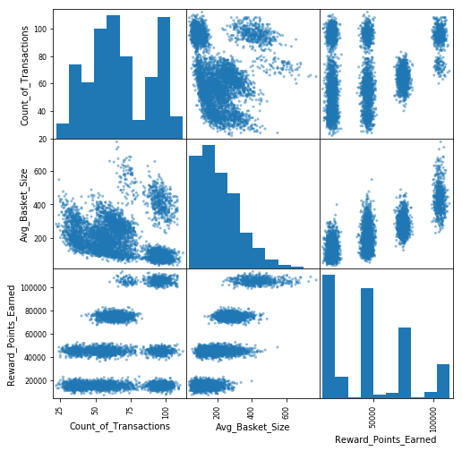

```python
customer_purchase.dropna(inplace=True)
pd.plotting.scatter_matrix(customer_purchase[['Count_of_Transactions','Avg_Basket_Size','Reward_Points_Earned']]
                           ,diagonal='hist',figsize = (8,8));
```

### Transforming Data

```python
skewed = ['Avg_Basket_Size','Reward_Points_Earned']
features_log_transformed_purchage = pd.DataFrame(data = customer_purchase)
features_log_transformed_purchage[skewed] = features_log_transformed_purchage[skewed].apply(lambda x: np.log(x + 1))
```

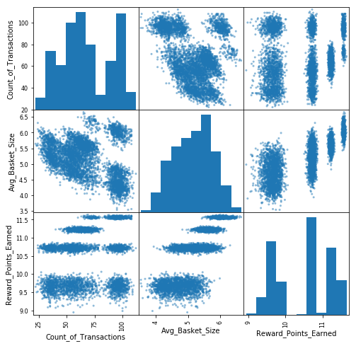

```python
#lets replot he data
pd.plotting.scatter_matrix(features_log_transformed_purchage[['Count_of_Transactions','Avg_Basket_Size','Reward_Points_Earned']]
                           ,diagonal='hist',figsize = (8,8));
```

### Customer monthly data

Since most of our data at customer level. I grouped the data at customer level and join all the data set

```python
customer_monthlly_groouped=customer_data_monthlly[['Customer_ID','Revenue','Cost','Net_Profit']].groupby('Customer_ID',as_index=False).mean()
customer_monthlly_groouped.head()
```

|  | Customer_ID | Revenue | Cost | Net_Profit |
| --- | --- | --- | --- | --- |
| 0 | 1 | 798.046667 | 704.122425 | 93.924242 |
| 1 | 2 | 843.015000 | 741.555683 | 101.459317 |
| 2 | 3 | 1143.240000 | 1003.617667 | 139.622333 |
| 3 | 4 | 500.138333 | 457.216067 | 42.922267 |
| 4 | 5 | 638.154167 | 581.438650 | 56.715517 |

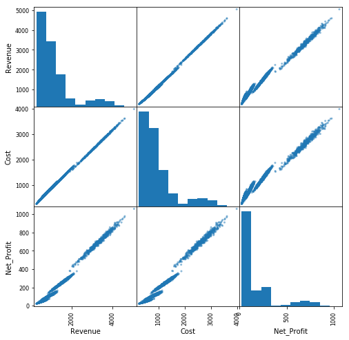

```python
pd.plotting.scatter_matrix(customer_monthlly_groouped[['Revenue','Cost','Net_Profit']]
                           ,diagonal='hist',figsize = (8,8));
```

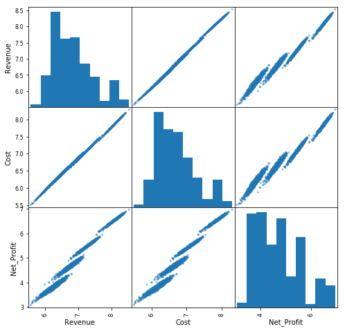

```python
skewed = ['Revenue','Cost','Net_Profit']
features_log_transformed_grouped = pd.DataFrame(data = customer_monthlly_groouped)
features_log_transformed_grouped[skewed] = customer_monthlly_groouped[skewed].apply(lambda x: np.log(x + 1))
#lets replot he data
pd.plotting.scatter_matrix(features_log_transformed_grouped[skewed]
                           ,diagonal='hist',figsize = (8,8));
```

```python
customer_socio_Economic.head()
```

|  | Customer_ID | month_last_contacted | Qtrly_Emp_variation_rate | Monthly_consumer_price_idx | Monthly_consumer_conf_idx | US_FED_3mnth_rate | Quarterly_num_of_emp |
| --- | --- | --- | --- | --- | --- | --- | --- |
| 0 | 1 | apr | -1.8 | 93.075 | -47.1 | 1.384 | 5099.1 |
| 1 | 2 | may | 1.1 | 93.994 | -36.4 | 4.864 | 5191.0 |
| 2 | 3 | apr | -1.8 | 93.075 | -47.1 | 1.453 | 5099.1 |
| 3 | 4 | jul | 1.4 | 93.918 | -42.7 | 4.961 | 5228.1 |
| 4 | 5 | nov | -0.1 | 93.200 | -42.0 | 4.120 | 5195.8 |

```python
campaign_coverage.head()
```

|  | Customer_ID | Mode_of_contact | month_last_contacted | day_of_week_last_contacted | duration_last_contact | num_of_contact_campaign | days_elapsed_last_contact | num_contact_before_campaigning | outcome_last_campaign | buy_decision_flag | Campaign_Start_Date | Duration_of_last_contact_type | Num_of_contact_campaign_type | Num_contact_before_campaign_type | Target_buy |
| --- | --- | --- | --- | --- | --- | --- | --- | --- | --- | --- | --- | --- | --- | --- | --- |
| 0 | 1 | flyers | apr | tue | 165 | 3 | 999 | 0 | nonexistent | no | 2/15/2016 | Short | Average | Average | 0 |
| 1 | 2 | mailers | may | fri | 43 | 2 | 999 | 0 | nonexistent | no | 2/15/2016 | Short | Average | Average | 0 |
| 2 | 3 | flyers | apr | tue | 369 | 1 | 999 | 0 | nonexistent | no | 2/15/2016 | Long | Once | Average | 0 |
| 3 | 4 | flyers | jul | tue | 500 | 1 | 999 | 0 | nonexistent | yes | 2/15/2016 | Long | Once | Average | 1 |
| 4 | 5 | flyers | nov | wed | 172 | 1 | 999 | 1 | failure | no | 2/15/2016 | Short | Once | Once | 0 |

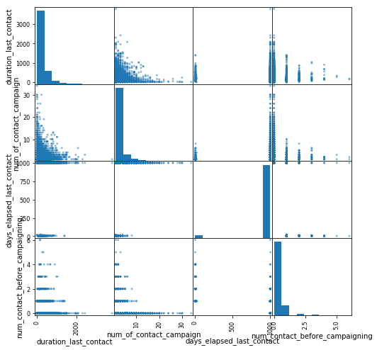

```python
pd.plotting.scatter_matrix(campaign_coverage[['duration_last_contact','num_of_contact_campaign','days_elapsed_last_contact'
                                            ,'num_contact_before_campaigning']],figsize=(8,8));
```

By looking at the above plot we can se that almost all the columns data is skewed. Since column **days_elapsed_last_contact** has most of the data as 999 I removed that column from the data set. I also removed the column **days_elapsed_last_contact and day_of_week_last_contacted** as the data is already available in other dataframe.

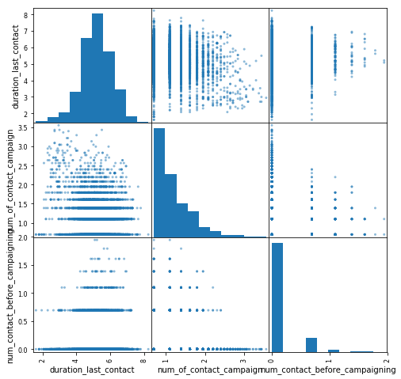

```python
campaign_coverage.drop(['days_elapsed_last_contact','month_last_contacted','day_of_week_last_contacted','Campaign_Start_Date'],axis=1,inplace=True)
skewed = ['duration_last_contact','num_of_contact_campaign','num_contact_before_campaigning']
features_log_transformed_campaing = pd.DataFrame(data = campaign_coverage)
features_log_transformed_campaing[skewed] = campaign_coverage[skewed].apply(lambda x: np.log(x + 1))
#lets replot he data
pd.plotting.scatter_matrix(features_log_transformed_campaing[skewed]
                           ,diagonal='hist',figsize = (8,8));
```

### Merge all the data frame and create a single dataset

At this stage I merge all the five dataset and create single dataset, So that we can make analysis at a single go

```python
customer_data=customer_profile.merge(features_log_transformed_purchage,how='inner')
customer_data=customer_data.merge(features_log_transformed_grouped,how='inner')
customer_data=customer_data.merge(features_log_transformed_campaing,how='inner')
customer_data=customer_data.merge(customer_socio_Economic,how='inner')
customer_data.head()
```

|  | index | Customer_ID | age | job | marital_status | education | Previous_Default_Flag | House_Owned_Flag | Loan_Availed_Flag | Income_USD | Credit_rating | Life_Stage_Code | Ethnicity | Employment | Count_of_Transactions | Loyalty_Tier | Avg_Basket_Size | Reward_Points_Earned | Revenue | Cost | Net_Profit | Mode_of_contact | duration_last_contact | num_of_contact_campaign | num_contact_before_campaigning | outcome_last_campaign | buy_decision_flag | Duration_of_last_contact_type | Num_of_contact_campaign_type | … |
| --- | --- | --- | --- | --- | --- | --- | --- | --- | --- | --- | --- | --- | --- | --- | --- | --- | --- | --- | --- | --- | --- | --- | --- | --- | --- | --- | --- | --- | --- | --- |
| 0 | 0 | 1 | 85 | retired | married | basic.4y | no | no | no | 10307 | Poor | Tradinationalist | African American | retired | 39 | Silver | 5.507576 | 10.745206 | 6.683419 | 6.558371 | 4.553079 | flyers | 5.111988 | 1.386294 | 0.000000 | nonexistent | no | Short | Average | … |
| 1 | 1 | 2 | 50 | blue-collar | married | basic.9y | no | no | no | 33232 | Fair | Baby Boomers | African American | employed | 37 | Silver | 5.614624 | 10.770420 | 6.738170 | 6.610098 | 4.629466 | mailers | 3.784190 | 1.098612 | 0.000000 | nonexistent | no | Short | Average | … |
| 2 | 2 | 3 | 47 | blue-collar | single | basic.4y | no | no | no | 12167 | Fair | Baby Boomers | African American | employed | 36 | Silver | 5.945630 | 10.660384 | 7.042496 | 6.912362 | 4.946078 | flyers | 5.913503 | 0.693147 | 0.000000 | nonexistent | no | Long | Once | … |
| 3 | 3 | 4 | 26 | technician | divorced | professional.course | no | no | yes | 26459 | Good | Gen Y | African American | employed | 32 | Bronze | 5.239373 | 9.663452 | 6.216882 | 6.127341 | 3.782421 | flyers | 6.216606 | 0.693147 | 0.000000 | nonexistent | yes | Long | Once | … |
| 4 | 4 | 5 | 52 | retired | married | university.degree | no | no | no | 22328 | Good | Baby Boomers | African American | retired | 39 | Bronze | 5.285005 | 9.385134 | 6.460146 | 6.367224 | 4.055526 | flyers | 5.153292 | 0.693147 | 0.693147 | failure | no | Short | Once | … |

### EDA with full dataset

In this section I checked for relationship between the numerical variable.

```python
target_buy = customer_data.pop('Target_buy')
```

```python
customer_data['income_group']= ['low' if income<=50000 else 'medium' if income >50000 and income <= 130000  else 'high'
                               for income in customer_data.Income_USD ]
```

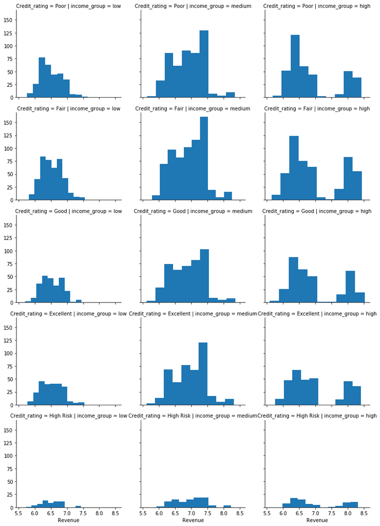

```python
g=sns.FacetGrid(row='Credit_rating',col='income_group',data=customer_data,aspect=1.2)
g.map(plt.hist,'Revenue')
```

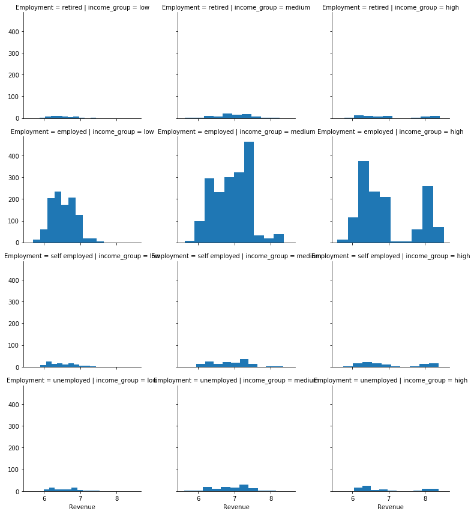

```python
g=sns.FacetGrid(row='Employment',col='income_group',data=customer_data,aspect=1.2)
g.map(plt.hist,'Revenue')
```

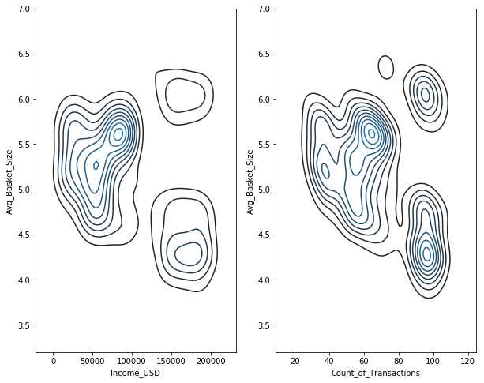

```python
fig, ax =plt.subplots(1,2, figsize=(10,8))
sns.kdeplot(customer_data.Income_USD,customer_data.Avg_Basket_Size,ax=ax[0])
sns.kdeplot(customer_data.Count_of_Transactions,customer_data.Avg_Basket_Size,ax=ax[1])
fig.show()
```

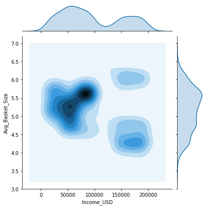

```python
sns.jointplot(customer_data.Income_USD,customer_data.Avg_Basket_Size,kind='kde')
```

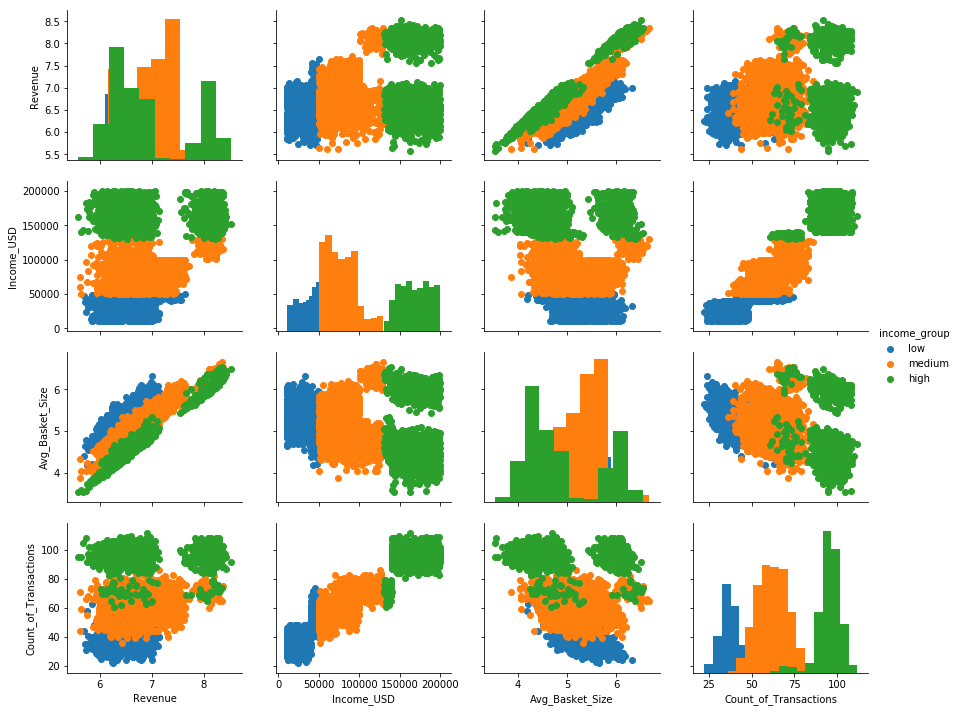

```python
g=sns.PairGrid(customer_data[['Revenue','Income_USD','Avg_Basket_Size','Count_of_Transactions','income_group']]
             ,hue='income_group',aspect=1.2)
g= g.map_diag(plt.hist)
g= g.map_offdiag(plt.scatter)
g= g.add_legend()
```

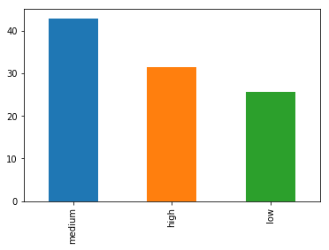

```python
(customer_data.income_group.value_counts()/customer_data.shape[0]*100).plot(kind='bar');
```

### Preparing the Data

Before data can be used as input for machine learning algorithms, it often must be cleaned, formatted, and restructured — this is typically known as **preprocessing**. Although most of the preprocessing I have done in previous section. Still I need to find the correlation between variables and use the best available for ML.

```python
temp1 = ['age', 'Income_USD', 'Avg_Basket_Size', 'Reward_Points_Earned', 'Revenue','Count_of_Transactions'
         ,'Cost','Net_Profit']
```

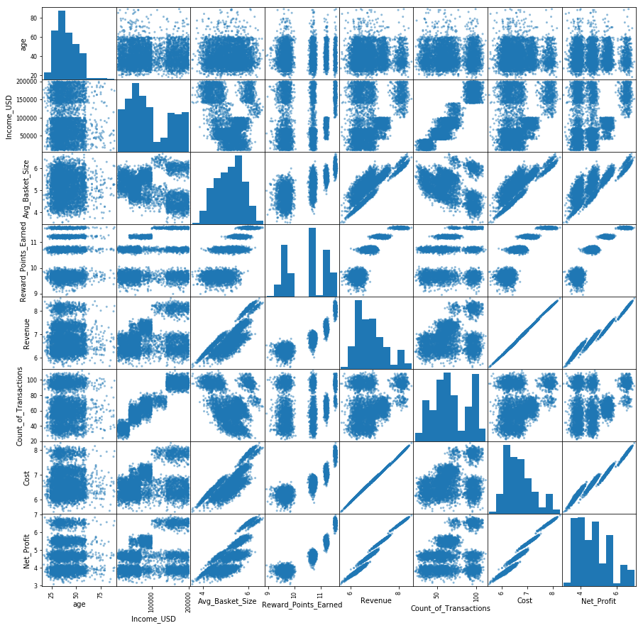

```python
pd.plotting.scatter_matrix(customer_data[temp1],figsize=(15,15));
```

By looking at the above figure we can see that there are some variable which are highly correlated. let’s remove them for further analysis

```python
temp2=['Revenue','Net_Profit','Avg_Basket_Size','Income_USD','Count_of_Transactions','Reward_Points_Earned','Cost']
customer_data[temp2].corr()
```

|  | Revenue | Net_Profit | Avg_Basket_Size | Income_USD | Count_of_Transactions | Reward_Points_Earned | Cost |
| --- | --- | --- | --- | --- | --- | --- | --- |
| Revenue | 1.000000 | 0.992287 | 0.825644 | 0.255913 | 0.269882 | 0.886144 | 0.999640 |
| Net_Profit | 0.992287 | 1.000000 | 0.822989 | 0.240210 | 0.256454 | 0.925853 | 0.988927 |
| Avg_Basket_Size | 0.825644 | 0.822989 | 1.000000 | -0.277242 | -0.311307 | 0.762805 | 0.825941 |
| Income_USD | 0.255913 | 0.240210 | -0.277242 | 1.000000 | 0.936163 | 0.146638 | 0.255680 |
| Count_of_Transactions | 0.269882 | 0.256454 | -0.311307 | 0.936163 | 1.000000 | 0.168267 | 0.269444 |
| Reward_Points_Earned | 0.886144 | 0.925853 | 0.762805 | 0.146638 | 0.168267 | 1.000000 | 0.878735 |
| Cost | 0.999640 | 0.988927 | 0.825941 | 0.255680 | 0.269444 | 0.878735 | 1.000000 |

By looking at the above table we can see that **Revenue, Net_Profit,Avg_Basket_Size,Reward_Points_Earned** are highly correlated. Also **Income_USD and Count_of_Transactions** are also highly correlated. So I only selected **Revenue and Income_USD** for future analysis

```python
customer_data.drop(['Net_Profit','Avg_Basket_Size','Reward_Points_Earned','Count_of_Transactions','Cost'],axis=1,inplace=True)
```

```python
# numerical = ['age', 'Income_USD', 'Avg_Basket_Size', 'Reward_Points_Earned', 'Revenue','Count_of_Transactions'
#             ,'Qtrly_Emp_variation_rate',' Monthly_consumer_price_idx','US_FED_3mnth_rate',
#             'Quarterly_num_of_emp','Cost','Net_Profit','Monthly_consumer_conf_idx','duration_last_contact','num_of_contact_campaign'
#             ,'days_elapsed_last_contact','num_contact_before_campaigning']
```

### Normalizing Numerical Features

Applying a scaling to the data does not change the shape of each feature's distribution, however normalization ensures that each feature is treated equally when applying supervised learners.

```python
numerical = ['age', 'Income_USD', 'Revenue','Qtrly_Emp_variation_rate',' Monthly_consumer_price_idx','US_FED_3mnth_rate',
             'Quarterly_num_of_emp','Monthly_consumer_conf_idx','duration_last_contact','num_of_contact_campaign'
             ,'num_contact_before_campaigning']
```

```python
scaler = MinMaxScaler() # default=(0, 1)
customer_data[numerical] = scaler.fit_transform(customer_data[numerical])

# Show an example of a record with scaling applied
customer_data.head(n = 5)
```

|  | index | Customer_ID | age | job | marital_status | education | Previous_Default_Flag | House_Owned_Flag | Loan_Availed_Flag | Income_USD | Credit_rating | Life_Stage_Code | Ethnicity | Employment | Loyalty_Tier | Revenue | Mode_of_contact | duration_last_contact | num_of_contact_campaign | num_contact_before_campaigning | outcome_last_campaign | buy_decision_flag | Duration_of_last_contact_type | Num_of_contact_campaign_type | Num_contact_before_campaign_type | month_last_contacted | Qtrly_Emp_variation_rate | Monthly_consumer_price_idx | Monthly_consumer_conf_idx | … |
| --- | --- | --- | --- | --- | --- | --- | --- | --- | --- | --- | --- | --- | --- | --- | --- | --- | --- | --- | --- | --- | --- | --- | --- | --- | --- | --- | --- | --- | --- | --- |
| 0 | 0 | 1 | 0.944444 | retired | married | basic.4y | no | no | no | 0.001601 | Poor | Tradinationalist | African American | retired | Silver | 0.374272 | flyers | 0.528318 | 0.242173 | 0.000000 | nonexistent | no | Short | Average | Average | apr | 0.333333 | 0.340608 | 0.154812 | … |
| 1 | 1 | 2 | 0.458333 | blue-collar | married | basic.9y | no | no | no | 0.122328 | Fair | Baby Boomers | African American | employed | Silver | 0.392868 | mailers | 0.328035 | 0.141662 | 0.000000 | nonexistent | no | Short | Average | Average | may | 0.937500 | 0.698753 | 0.602510 | … |
| 2 | 2 | 3 | 0.416667 | blue-collar | single | basic.4y | no | no | no | 0.011396 | Fair | Baby Boomers | African American | employed | Silver | 0.496231 | flyers | 0.649217 | 0.000000 | 0.000000 | nonexistent | no | Long | Once | Average | apr | 0.333333 | 0.340608 | 0.154812 | … |
| 3 | 3 | 4 | 0.125000 | technician | divorced | professional.course | no | no | yes | 0.086660 | Good | Gen Y | African American | employed | Bronze | 0.215814 | flyers | 0.694936 | 0.000000 | 0.000000 | nonexistent | yes | Long | Once | Average | jul | 1.000000 | 0.669135 | 0.338912 | … |
| 4 | 4 | 5 | 0.486111 | retired | married | university.degree | no | no | no | 0.064906 | Good | Baby Boomers | African American | retired | Bronze | 0.298438 | flyers | 0.534548 | 0.000000 | 0.356207 | failure | no | Short | Once | Once | nov | 0.687500 | 0.389322 | 0.368201 | … |

### Removing non-informative and duplicate columns

The columns with unique id every row dose not provide any info in learning. So I removed the customer_Id colums. And also, the buy_decision_flag is same as our target variable. Its just duplicate columns for our target variable. Keeping it will give us misleading output. (such as very high accuracy)

From the table in Exploring the Data above, we can see there are several features for each record that are non-numeric. Typically, learning algorithms expect input to be numeric, which requires that non-numeric features (called categorical variables) be converted. One popular way to convert categorical variables is by using the one-hot encoding scheme. One-hot encoding creates a "dummy" variable for each possible category of each non-numeric feature.

```python
customer_data.drop(['index','Customer_ID','buy_decision_flag'],inplace=True,axis=1)
features_coded = pd.get_dummies(customer_data)
# Print the number of features after one-hot encoding
encoded = list(features_coded.columns)
print("{} total features after one-hot encoding.".format(len(encoded)))
# Uncomment the following line to see the encoded feature names
# print encoded
```

```
90 total features after one-hot encoding.
```

### Shuffle and Split Data

Now all *categorical variables* have been converted into numerical features, and all numerical features have been normalized. As always, we will now split the data (both features and their labels) into training and test sets. 80% of the data will be used for training and 20% for testing.

```python
target_buy= pd.get_dummies(target_buy,drop_first=True)
# Split the 'features' and 'income' data into training and testing sets
X_train, X_test, y_train, y_test = train_test_split(features_coded,
                                                    target_buy,
                                                    test_size = 0.20,
                                                    random_state = 124)

# Show the results of the split
print("Training set has {} samples.".format(X_train.shape[0]))
print("Testing set has {} samples.".format(X_test.shape[0]))
print("Training set has {:.1f}% positive samples.".format(*(y_train.sum()/y_train.shape[0])*100))
print("Training set has {:.1f}% positive samples.".format(*(y_test.sum()/y_test.shape[0])*100))
```

```
Training set has 4025 samples.
Testing set has 1007 samples.
Training set has 11.2% positive samples.
Training set has 11.9% positive samples.
```

By looking at above stats its look that the data is evenly destributed.

## Evaluating Model Performance

### Metrics and the Naive Predictor

With *Camping Coverage*, we want to connect to only those customer who are likely to by response positive. It would seem that using **accuracy** as a metric for evaluating a particular model's performance would be appropriate. Since we are looking to find individuals with positive response, Therefore, a model's ability to precisely predict those that are likely to be positive response is *more important* than the model's ability to **recall** those individuals. We can use **F-beta score** as a metric that considers both precision and recall:

$$ F_{\beta} = (1 + \beta^2) \cdot \frac{precision \cdot recall}{\left( \beta^2 \cdot precision \right) + recall} $$

**Accuracy** measures how often the classifier makes the correct prediction. It’s the ratio of the number of correct predictions to the total number of predictions (the number of test data points).

**Precision** tells us what proportion of messages we classified as spam, actually were spam. It is a ratio of true positives(words classified as spam, and which are actually spam) to all positives(all words classified as spam, irrespective of whether that was the correct classificatio), in other words it is the ratio of

`[True Positives/(True Positives + False Positives)]`

**Recall(sensitivity)** tells us what proportion of messages that actually were spam were classified by us as spam. It is a ratio of true positives(words classified as spam, and which are actually spam) to all the words that were actually spam, in other words it is the ratio of

`[True Positives/(True Positives + False Negatives)]`

For classification problems that are skewed in their classification distributions like in our case, for example if we had a 100 text messages and only 2 were spam and the rest 98 weren't, accuracy by itself is not a very good metric. We could classify 90 messages as not spam(including the 2 that were spam but we classify them as not spam, hence they would be false negatives) and 10 as spam(all 10 false positives) and still get a reasonably good accuracy score. For such cases, precision and recall come in very handy. These two metrics can be combined to get the F1 score, which is weighted average(harmonic mean) of the precision and recall scores. This score can range from 0 to 1, with 1 being the best possible F1 score(we take the harmonic mean as we are dealing with ratios).

```python
'''
TP = np.sum(targer_buy) # Counting the ones as this is the naive case.
FP = targer_buy.count() - TP # Specific to the naive case

TN = 0 # No predicted negatives in the naive case
FN = 0 # No predicted negatives in the naive case
'''
# TODO: Calculate accuracy, precision and recall
accuracy = float(np.sum(target_buy))/float(target_buy.count())
precision = float(np.sum(target_buy))/float(target_buy.count())
recall  = float(np.sum(target_buy))/float(np.sum(target_buy))


# TODO: Calculate F-score using the formula above for beta = 0.5 and correct values for precision and recall.
fscore = (1+.5*.5)*(recall*precision)/((.5*.5*precision)+recall)

# Print the results
print("Naive Predictor: [Accuracy score: {:.4f}, F-score: {:.4f}]".format(accuracy, fscore))
```

```
Naive Predictor: [Accuracy score: 0.1135, F-score: 0.1379]
```

### Implementation - Creating a Training and Predicting Pipeline

To properly evaluate the performance of each model, it's important that you create a training and predicting pipeline that allows us to quickly and effectively train models using various sizes of training data and perform predictions on the testing data.

- Import `fbeta_score` and `accuracy_score` from `sklearn.metrics`
- Fit the learner to the sampled training data and record the training time.
- Perform predictions on the test data `X_test`, and also on the training points `X_train`.
- Calculate the accuracy score for both the training subset and testing set.
- Calculate the F-score for both the training subset and testing set.

```python
from time import time
from sklearn.metrics import accuracy_score,fbeta_score, precision_score,recall_score
def train_predict(learner, X_train, y_train, X_test, y_test):
    '''
    inputs:
       - learner: the learning algorithm to be trained and predicted on
       - sample_size: the size of samples (number) to be drawn from training set
       - X_train: features training set
       - y_train: income training set
       - X_test: features testing set
       - y_test: income testing set
    '''

    results = {}
    start= time()
    y_train= np.array(y_train).ravel()
    learner.fit(X_train,y_train)
    end= time()
    predictions_test = learner.predict_proba(X_test)
    df_test= pd.DataFrame(predictions_test)
    predictions_test= np.array([0 if x<=.5 else 1 for x in df_test[1]])
    predictions_train = learner.predict_proba(X_train)
    df_train= pd.DataFrame(predictions_train)
    predictions_train= np.array([0 if x<=.50 else 1 for x in  df_train[1]])
    # TODO: Compute accuracy on the first 300 training samples which is y_train[:300]
    results['precision_score']= precision_score(y_test,predictions_test)
    results['recall_score']= recall_score(y_test,predictions_test)

    results['acc_train'] = accuracy_score(y_train,predictions_train)

    # TODO: Compute accuracy on test set using accuracy_score()
    results['acc_test'] = accuracy_score(y_test,predictions_test)

    # TODO: Compute F-score on the the first 300 training samples using fbeta_score()
    results['f_train'] = fbeta_score(y_train,predictions_train,beta=.5)

    # TODO: Compute F-score on the test set which is y_test
    results['f_test'] =  fbeta_score(y_test,predictions_test,beta=.5)

    results['train_time']= end-start
    # Return the results
    return results
```

### Implementation: Initial Model Evaluation

- Initialize the three models and store them in `'clf_A'`, `'clf_B'`, and `'clf_C'`.
  - Use a `'random_state'` for each model.
  - Use the default settings for each model — we will tune one specific model in a later section.

```python
from sklearn.linear_model import LogisticRegression
from sklearn.tree import DecisionTreeClassifier
from sklearn.ensemble import AdaBoostClassifier
from sklearn.ensemble import RandomForestClassifier
from sklearn.svm import SVC
from sklearn.model_selection import train_test_split


# TODO: Initialize the three models
clf_A = LogisticRegression()
clf_B = AdaBoostClassifier()
clf_C = DecisionTreeClassifier()
clf_D = RandomForestClassifier()
# TODO: Calculate the number of samples for 1%, 10%, and 100% of the training data
# HINT: samples_100 is the entire training set i.e. len(y_train)
# HINT: samples_10 is 10% of samples_100 (ensure to set the count of the values to be `int` and not `float`)
# HINT: samples_1 is 1% of samples_100 (ensure to set the count of the values to be `int` and not `float`
# Collect results on the learners
results = {}
for clf in [clf_A,clf_B,clf_C,clf_D]:
    clf_name = clf.__class__.__name__
    results[clf_name] = {}
    results[clf_name] = \
    train_predict(clf, X_train, y_train, X_test, y_test)
```

```python
results
```

```
{'AdaBoostClassifier': {'acc_test': 0.9066534260178749,
  'acc_train': 0.9172670807453416,
  'f_test': 0.6004901960784313,
  'f_train': 0.6329113924050632,
  'precision_score': 0.6805555555555556,
  'recall_score': 0.4083333333333333,
  'train_time': 0.2962632179260254},
 'DecisionTreeClassifier': {'acc_test': 0.8788480635551142,
  'acc_train': 1.0,
  'f_test': 0.4898648648648649,
  'f_train': 1.0,
  'precision_score': 0.4915254237288136,
  'recall_score': 0.48333333333333334,
  'train_time': 0.045851945877075195},
 'LogisticRegression': {'acc_test': 0.9076464746772592,
  'acc_train': 0.9137888198757764,
  'f_test': 0.6034482758620688,
  'f_train': 0.6101694915254237,
  'precision_score': 0.7368421052631579,
  'recall_score': 0.35,
  'train_time': 0.033390045166015625},
 'RandomForestClassifier': {'acc_test': 0.9026812313803376,
  'acc_train': 0.9925465838509316,
  'f_test': 0.5729166666666666,
  'f_train': 0.9846010265982267,
  'precision_score': 0.6666666666666666,
  'recall_score': 0.36666666666666664,
  'train_time': 0.046890974044799805}}
```

## Improving Results

```python
from sklearn.model_selection import GridSearchCV
from sklearn.ensemble import AdaBoostClassifier
from sklearn.ensemble import RandomForestClassifier
from sklearn.metrics import make_scorer,fbeta_score, confusion_matrix

# TODO: Initialize the classifier
clf = AdaBoostClassifier()
#clf= RandomForestClassifier()
y_train= np.array(y_train).ravel()
# TODO: Create the parameters list you wish to tune, using a dictionary if needed.
# HINT: parameters = {'parameter_1': [value1, value2], 'parameter_2': [value1, value2]}
parameters = {'learning_rate':[1,1.2,1.5,2],'n_estimators':[80,100,150,200]}
# parameters={'bootstrap': [True, False],
#             'max_depth': [4,6,8,10,20],
#             'max_features': ['auto', 'sqrt'],
#             'min_samples_leaf': [ 2, 4,6],
#             'min_samples_split': [2, 5, 10],
#             'n_estimators': [10,15,20,50]}
# TODO: Make an fbeta_score scoring object using make_scorer()
scorer = make_scorer(fbeta_score)

# TODO: Perform grid search on the classifier using 'scorer' as the scoring method using GridSearchCV()
grid_obj = GridSearchCV(clf,param_grid=parameters)

# TODO: Fit the grid search object to the training data and find the optimal parameters using fit()
grid_fit = grid_obj.fit(X_train,y_train)

# Get the estimator
best_clf = grid_fit.best_estimator_

# Make predictions using the unoptimized and model
predictions = (clf.fit(X_train, y_train)).predict(X_test)
best_predictions = best_clf.predict(X_test)
```

```python
# Report the before-and-afterscores
print("Unoptimized model\n------")
print("Accuracy score on testing data: {:.4f}".format(accuracy_score(y_test, predictions)))
print("F-score on testing data: {:.4f}".format(fbeta_score(y_test, predictions, beta = .5)))
print("\nOptimized Model\n------")
print("Final accuracy score on the testing data: {:.4f}".format(accuracy_score(y_test, best_predictions)))
print("Final F-score on the testing data: {:.4f}".format(fbeta_score(y_test, best_predictions, beta = .5)))
```

```
Unoptimized model
------
Accuracy score on testing data: 0.9067
F-score on testing data: 0.6005

Optimized Model
------
Final accuracy score on the testing data: 0.9096
Final F-score on the testing data: 0.6189
```

#### Results:

| Metric | Unoptimized Model | Optimized Model |
| --- | --- | --- |
| Accuracy Score | 0.9067 | 0.9096 |
| F-score | 0.6005 | 0.6189 |

From the above table we find out that both optimized and unoptimized adaboost perform significantly better than the naive model. The optimized model perform slightly better than unoptimized mode.

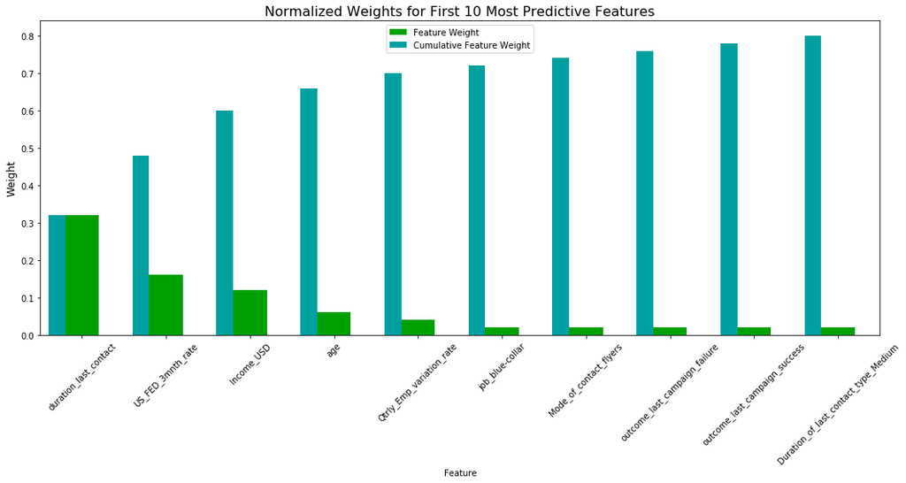

```python
 importances=clf.feature_importances_

def feature_plot(importances, X_train, y_train):

    # Display the five most important features
    indices = np.argsort(importances)[::-1]
    columns = X_train.columns.values[indices[:10]]
    values = importances[indices][:10]

    # Creat the plot
    fig = plt.figure(figsize = (15,8))
    plt.title("Normalized Weights for First 10 Most Predictive Features", fontsize = 16)
    plt.bar(np.arange(10), values, width = 0.4, align="center", color = '#00A000', \
          label = "Feature Weight")
    plt.bar(np.arange(10) - 0.3, np.cumsum(values), width = 0.2, align = "center", color = '#00A0A0', \
          label = "Cumulative Feature Weight")
    plt.xticks(np.arange(10), columns,rotation=45)
    plt.xlim((-0.5, 9.5))
    plt.ylabel("Weight", fontsize = 12)
    plt.xlabel("Feature")

    plt.legend(loc = 'upper center')
    plt.tight_layout()
    plt.show()

feature_plot(importances, X_train, y_train)
```

```python
#Using PCA to reduce the number of dimension

# from sklearn.decomposition import PCA
# pca= PCA()
# pca_sample=pca.fit_transform(features_coded)
# fig, ax = plt.subplots(figsize=(14, 5))
# sns.set(font_scale=1)
# plt.step(range(features_coded.shape[1]), pca.explained_variance_ratio_.cumsum(), where='mid', label='cumulative explained variance')
# sns.barplot(np.arange(1,features_coded.shape[1]+1), pca.explained_variance_ratio_, alpha=0.5, color = 'g',label='individual explained variance')

# plt.xlim(0, 100)

# ax.set_xticklabels([s if int(s.get_text())%2 == 0 else '' for s in ax.get_xticklabels()])

# plt.ylabel('Explained variance', fontsize = 14)
# plt.xlabel('Principal components', fontsize = 14)
# plt.legend(loc='lower right', fontsize = 13);
```

```python
# pca= PCA(n_components=50)
# feature_final=pca.fit_transform(features_coded)
# from sklearn.model_selection import train_test_split

# # Split the 'features' and 'income' data into training and testing sets
# X_train, X_test, y_train, y_test = train_test_split(feature_final,
#                                                     target_buy,
#                                                     test_size = 0.20,
#                                                     random_state = 124)

# # Show the results of the split
# print("Training set has {} samples.".format(X_train.shape[0]))
# print("Testing set has {} samples.".format(X_test.shape[0]))
```

```python
# results = {}
# for clf in [clf_A,clf_B,clf_C,clf_D]:
#     clf_name = clf.__class__.__name__
#     results[clf_name] = {}
#     results[clf_name] = \
#     train_predict(clf, X_train, y_train, X_test, y_test)
# results
```

```python
# from sklearn.model_selection import GridSearchCV
# from sklearn.ensemble import AdaBoostClassifier
# from sklearn.linear_model import LogisticRegression
# from sklearn.metrics import make_scorer,fbeta_score

# # TODO: Initialize the classifier
# #clf = AdaBoostClassifier()
# clf= LogisticRegression()
# y_train= np.array(y_train).ravel()
# # TODO: Create the parameters list you wish to tune, using a dictionary if needed.
# # HINT: parameters = {'parameter_1': [value1, value2], 'parameter_2': [value1, value2]}
# parameters = {'C':[.1,.5,.8,1,10]}
# #parameters = {'learning_rate':[1,1.2,1.5,2],'n_estimators':[80,100,150,200]}

# # TODO: Make an fbeta_score scoring object using make_scorer()
# scorer = make_scorer(fbeta_score)

# # TODO: Perform grid search on the classifier using 'scorer' as the scoring method using GridSearchCV()
# grid_obj = GridSearchCV(clf,param_grid=parameters)

# # TODO: Fit the grid search object to the training data and find the optimal parameters using fit()
# grid_fit = grid_obj.fit(X_train,y_train)

# # Get the estimator
# best_clf = grid_fit.best_estimator_

# # Make predictions using the unoptimized and model
# predictions = (clf.fit(X_train, y_train)).predict(X_test)
# best_predictions = best_clf.predict(X_test)
# best_predictions_pro = best_clf.predict_proba(X_test)
# # Report the before-and-afterscores
# print("Unoptimized model\n------")
# print("Final precision score on the testing data: {:.4f}".format(precision_score(y_test, predictions)))
# print("Final recall on the testing data: {:.4f}".format(recall_score(y_test, predictions)))
# print("Accuracy score on testing data: {:.4f}".format(accuracy_score(y_test, predictions)))
# print("F-score on testing data: {:.4f}".format(fbeta_score(y_test, predictions, beta = 0.5)))
# print("\nOptimized Model\n------")
# print("Final precision score on the testing data: {:.4f}".format(precision_score(y_test, best_predictions)))
# print("Final recall on the testing data: {:.4f}".format(recall_score(y_test, best_predictions)))
# print("Final accuracy score on the testing data: {:.4f}".format(accuracy_score(y_test, best_predictions)))
# print("Final F-score on the testing data: {:.4f}".format(fbeta_score(y_test, best_predictions, beta = 0.5)))
```